# Computing Assignment 10: STAT 417 - Survival Analysis Methods

Author

Andrew Kerr

In this assignment, you’ll examine attendance data from Winter 2025 to investigate the time until first absence. The file `AttendanceW2025.txt` located in the Computing Assignment Week 10 folder contains the time (number of days) until first absence (measured from the student’s first day of class), as well as measurements on two explanatory variables described below:

- **Time**: Time until first absence (days).
- **C**: Censoring status variable. $1 =$ time is complete, $0 =$ student still has not been absent.
- **Gender**: The self-identified gender of the student: female or male (the reference group will be female students when the model is fit).
- **STATMajor**: Whether the student is a Statistics major: yes or no (the reference group will be “No” when the model is fit).

## Question 1

Import the data into your R session and examine the Kaplan-Meier curves using the following syntax:

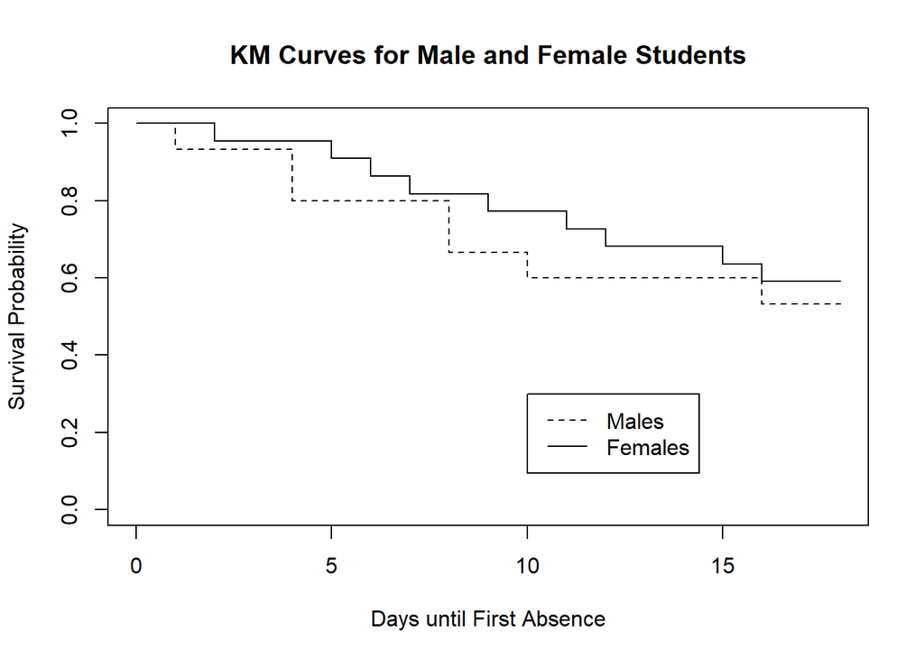

```r
KM.obj <- survfit(Surv(Time,C)~Gender,conf.type="none", data=AttendanceW2025)

plot(KM.obj,lty=1:2,xlab="Days until First Absence", ylab="Survival Probability",

main="KM Curves for Male and Female Students")

legend(10,.3, c("Males","Females"),lty=2:1)
```

What do you observe?

## Question 2

Fit the exponential regression model that includes the predictors Gender and STATMajor. Use the following syntax to guide you:

```r
exp.obj <- survreg(
  Surv(Time,C)~Gender+STATMajor,
  data=AttendanceW2025,
  dist="exponential"
  )

summary(exp.obj)
```

```
Call:
survreg(formula = Surv(Time, C) ~ Gender + STATMajor, data = AttendanceW2025,
    dist = "exponential")
              Value Std. Error     z       p
(Intercept)   3.401      1.000  3.40 0.00067
GenderM      -0.253      0.518 -0.49 0.62502
STATMajorYes  0.179      1.061  0.17 0.86610

Scale fixed at 1

Exponential distribution
Loglik(model)= -71.3   Loglik(intercept only)= -71.5
    Chisq= 0.24 on 2 degrees of freedom, p= 0.89
Number of Newton-Raphson Iterations: 4
n= 37
```

Based on the summary of results of the fitted model, answer the following:

1. Estimate how much higher or lower (as a percentage change) the time until first absence is for a Statistics major compared to a non-Statistics major adjusting for gender.

   The time until first absence for statistics majors is estimated to be 19.6% longer than the times to first absence for non-statistics majors.
2. Predict the median time until first absence for a male student who is not a Statistics major.

   ```r
   cat("median:", -log(.5) * exp(3.401 - 0.253), "days")
   ```

   ```
   median: 16.14301 days
   ```

3. Write out the expressions for the estimated predictor-adjusted survival function and hazard function using the parameter estimates of your model.

   $$S(t|X_1, X_2) = exp[\frac{-t}{exp(3.401 - 0.253x_1 + 0.179x_2)}]$$

   $$h(t|X_1, X_2) = \frac{1}{exp(3.401 - 0.253x_1 + 0.179x_2)}$$
4. Is either explanatory variable significantly useful in the presence of the other? Justify your answer.

   Neither explanatory variable is significantly useful because the Wald test results is large p-values for both predictors (0.63 and 0.87 respectively).
5. Compute the estimated mean time to first absence for a female student who is a Statistics major.

   ```r
   cat("mean time:", exp(3.401 + 0.179), "days")
   ```

   ```
   mean time: 35.87354 days
   ```

6. Compute and interpret the estimated time ratio comparing male students who are not Statistics majors to male students who are Statistics majors.

   ```r
   cat("est. TR:", exp(-0.179))
   ```

   ```
   est. TR: 0.8361059
   ```

   The estimated time to first absence for male students that are not statistics majors is 16.39% faster than that for male students that are statistics majors.
7. Compute the estimated hazard ratio comparing male students who are not Statistics majors to male students who are Statistics majors.

   ```r
   cat("est. HR:", exp(0.179))
   ```

   ```
   est. HR: 1.196021
   ```

8. Construct a 95% confidence interval for the hazard ratio that you estimated above.

   ```r
   exp(-(0.179 %+-% 1.96 * 1.061))
   ```

   ```
   [1] 0.103366 6.616993
   ```

## Question 3

Fit a Weibull regression model that includes the predictors Gender and STATMajor. The syntax will be similar to that used for the exponential regression model, but specify `dist="weibull"` in the `survreg` statement. Based on the summary of results of the fitted model, answer the following:

```r
weibull.obj <- survreg(
  Surv(Time,C)~Gender+STATMajor,
  data=AttendanceW2025,
  dist="weibull"
  )

summary(weibull.obj)
```

```
Call:
survreg(formula = Surv(Time, C) ~ Gender + STATMajor, data = AttendanceW2025,
    dist = "weibull")
              Value Std. Error     z       p
(Intercept)   3.294      0.851  3.87 0.00011
GenderM      -0.219      0.437 -0.50 0.61705
STATMajorYes  0.155      0.892  0.17 0.86216
Log(scale)   -0.174      0.232 -0.75 0.45476

Scale= 0.841

Weibull distribution
Loglik(model)= -71.1   Loglik(intercept only)= -71.2
    Chisq= 0.25 on 2 degrees of freedom, p= 0.88
Number of Newton-Raphson Iterations: 5
n= 37
```

1. Predict the median time until first absence for a male student who is not a Statistics major. How does your answer compare to that obtained using the exponential regression model in Problem 1(d)?

   ```r
   cat("median:", (-log(.5))**0.841 * exp(3.294 - 0.219), "days")
   ```

   ```
   median: 15.90705 days
   ```

   This is smaller compared to my answer using the exponential distribution (16.14301 days).
2. Perform the appropriate test at the $0.1$ significance level to determine if the Weibull model is more appropriate to use than the exponential model. Justify your answer.

   With a test-statistic = -0.75 and a p-value = 0.45476, at the 0.1 significance level we can not conclude that the Weibull regression model is a significant improvement over the Exponential regression model.